# quiz1

## The Gapminder bubble chart

We will use the Gapminder data that you are seen in lab and in the tutorials. I have kept the attributes that are relevant to this exercise

| Column | Description |
| --- | --- |
| country | Country name |
| year | Year of observation |
| population | Population in the country at each year |
| region | Continent the country belongs to |
| sub_region | Sub-region the country belongs to |
| income_group | Income group [as specified by the world bank in 2018](https://datahelpdesk.worldbank.org/knowledgebase/articles/378833-how-are-the-income-group-thresholds-determined) |
| income | GDP per capita (in USD) adjusted for differences in purchasing power |
| children_per_woman | Average number of children born per woman |

```python
# Run this cell to ensure that altair plots show up on gradescope
import altair as alt
import pandas as pd

# Handle large data sets without embedding them in the notebook
alt.data_transformers.enable('data_server')
# Include an image for each plot since Gradescope only supports displaying plots as images
alt.renderers.enable('mimetype')


url = 'https://raw.githubusercontent.com/UofTCoders/workshops-dc-py/master/data/processed/world-data-gapminder.csv'
# Read in the data using pandas
gm = pd.read_csv(url, parse_dates=['year'])

gm.head()
```

|  | country | year | population | region | sub_region | income_group | life_expectancy | income | children_per_woman | child_mortality | pop_density | co2_per_capita | years_in_school_men | years_in_school_women |
| --- | --- | --- | --- | --- | --- | --- | --- | --- | --- | --- | --- | --- | --- | --- |
| 0 | Afghanistan | 1800-01-01 | 3280000 | Asia | Southern Asia | Low | 28.2 | 603 | 7.0 | 469.0 | NaN | NaN | NaN | NaN |
| 1 | Afghanistan | 1801-01-01 | 3280000 | Asia | Southern Asia | Low | 28.2 | 603 | 7.0 | 469.0 | NaN | NaN | NaN | NaN |
| 2 | Afghanistan | 1802-01-01 | 3280000 | Asia | Southern Asia | Low | 28.2 | 603 | 7.0 | 469.0 | NaN | NaN | NaN | NaN |
| 3 | Afghanistan | 1803-01-01 | 3280000 | Asia | Southern Asia | Low | 28.2 | 603 | 7.0 | 469.0 | NaN | NaN | NaN | NaN |
| 4 | Afghanistan | 1804-01-01 | 3280000 | Asia | Southern Asia | Low | 28.2 | 603 | 7.0 | 469.0 | NaN | NaN | NaN | NaN |

### Question 1

Filter the dataframe to only keep observations from the year 2018 and from countries in the region of Asia and assign this to a new variable name `gm_2018_asia`. Dates can be matched as strings when filtering. Finally show the first 15 rows of the dataframe.

```python
gm_2018_asia = gm.query("year == 2018 & region == 'Asia'")
# Print the top 15 rows of the data frame
gm_2018_asia.head(15)
```

|  | country | year | population | region | sub_region | income_group | life_expectancy | income | children_per_woman | child_mortality | pop_density | co2_per_capita | years_in_school_men | years_in_school_women |
| --- | --- | --- | --- | --- | --- | --- | --- | --- | --- | --- | --- | --- | --- | --- |
| 218 | Afghanistan | 2018-01-01 | 36400000 | Asia | Southern Asia | Low | 58.7 | 1870 | 4.33 | 65.90 | 55.7 | NaN | NaN | NaN |
| 1532 | Armenia | 2018-01-01 | 2930000 | Asia | Western Asia | Upper middle | 76.0 | 8660 | 1.60 | 12.90 | 103.0 | NaN | NaN | NaN |
| 2189 | Azerbaijan | 2018-01-01 | 9920000 | Asia | Western Asia | Upper middle | 72.3 | 16600 | 2.04 | 30.30 | 120.0 | NaN | NaN | NaN |
| 2627 | Bahrain | 2018-01-01 | 1570000 | Asia | Western Asia | High | 77.2 | 44300 | 1.99 | 7.10 | 2060.0 | NaN | NaN | NaN |
| 2846 | Bangladesh | 2018-01-01 | 166000000 | Asia | Southern Asia | Lower middle | 73.4 | 3720 | 2.05 | 32.00 | 1280.0 | NaN | NaN | NaN |
| 4160 | Bhutan | 2018-01-01 | 817000 | Asia | Southern Asia | Lower middle | 74.8 | 9930 | 1.99 | 29.50 | 21.4 | NaN | NaN | NaN |
| 5912 | Cambodia | 2018-01-01 | 16200000 | Asia | South-eastern Asia | Lower middle | 69.3 | 3830 | 2.50 | 27.00 | 92.0 | NaN | NaN | NaN |
| 7226 | China | 2018-01-01 | 1420000000 | Asia | Eastern Asia | Upper middle | 76.9 | 16000 | 1.64 | 9.95 | 151.0 | NaN | NaN | NaN |
| 9197 | Cyprus | 2018-01-01 | 1190000 | Asia | Western Asia | High | 80.8 | 32200 | 1.34 | 2.45 | 129.0 | NaN | NaN | NaN |
| 12920 | Georgia | 2018-01-01 | 3910000 | Asia | Western Asia | Lower middle | 74.3 | 10100 | 1.98 | 10.60 | 56.2 | NaN | NaN | NaN |
| 15767 | India | 2018-01-01 | 1350000000 | Asia | Southern Asia | Lower middle | 69.1 | 6890 | 2.28 | 41.10 | 455.0 | NaN | NaN | NaN |
| 15986 | Indonesia | 2018-01-01 | 267000000 | Asia | South-eastern Asia | Lower middle | 72.0 | 11700 | 2.31 | 25.00 | 147.0 | NaN | NaN | NaN |
| 16205 | Iran | 2018-01-01 | 82000000 | Asia | Southern Asia | Upper middle | 76.5 | 17400 | 1.61 | 13.90 | 50.4 | NaN | NaN | NaN |
| 16424 | Iraq | 2018-01-01 | 39300000 | Asia | Western Asia | Upper middle | 68.0 | 15900 | 4.25 | 29.20 | 90.6 | NaN | NaN | NaN |
| 16862 | Israel | 2018-01-01 | 8450000 | Asia | Western Asia | High | 82.4 | 33400 | 2.92 | 3.33 | 391.0 | NaN | NaN | NaN |

### Question 2

Using the `gm_2018_asia` dataframe, create a bubble chart with the following

1. use the circle mark
2. `income` using the vertical position channel (x)
3. `income_group` using the horizontal position channel (y)
4. `children_per_woman`using the color channel (note depending on the data attribute type altair will either use color hue or saturation
5. `sub_region` using the size channel

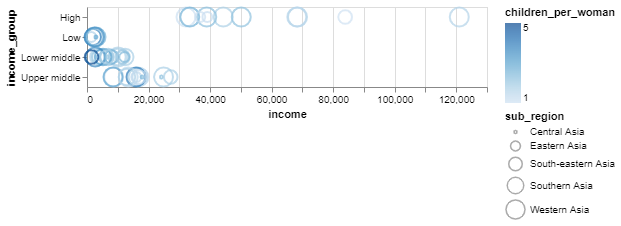

```python
chart_fert_money = alt.Chart(gm_2018_asia).mark_point().encode(
    x = "income:Q",# vertical position channel
    y = "income_group:O", # horizontal position channel
    color = "children_per_woman:Q",
    size = "sub_region:N"
)
# Show the plot
chart_fert_money
```

### Questions 3 - 6

Critique the visualization above by doing the following:

- Describe the data attributes and the types used for each data
- Discuss the benefits of using certain channels to encode specific attributes
- Name one question that the visualization is good at answering in its current state
- Name one question that the visualization is not good at answering

## 3 Describe the data attributes and the types used for each data

The data attributes here are `income`, `income_group`, `children_per_woman` ,and `sub_region`. Each of their attribute meaning is the following:

- sub_region Sub-region the country belongs to
- income_group Income group [as specified by the world bank in 2018]
- income GDP per capita (in USD) adjusted for differences in purchasing power
- children_per_woman Average number of children born per woman

The types of each are quantitative, ordinal, quantitative, nominal, in that order. This would make sense, since `income` consists of actual or real-value quantity of money people earned, `income_group` has natural groupings of levels, where High is top, and Low is min; `Children_per_woman` also could be expressed by real-valued quantity, lastly, `sub_region` consists of different categories, where there's no such who comes first so nominal would be its type.

## 4 Discuss the benefits of using certain channels to encode specific attributes

Using bubble chart with a known scale of axis could already explain information on income quite well, the use of `color` and `size` channel could help us ilustrate which group of people belonging to a sub_region gains more than others.

## 5 Name one question that the visualization is good at answering in its current state

Describing the groups of people income of Asia in the year of 2018

## 6 Name one question that the visualization is not good at answering

What are the chareteristics of people with most income? (And not effective order in ordinal channel), and the axis are inverted

### Question 7

Using, your answer for the last question (i.e., Q6) redesign the bubble chart (from Q2) by changing which attribute each of the 4 given channels encode.

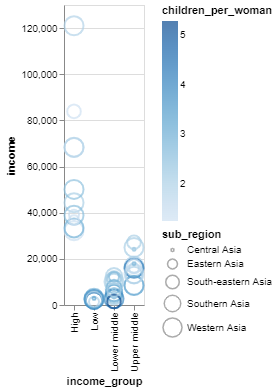

```python
my_chart = alt.Chart(gm_2018_asia).mark_point().encode(
    y = "income:Q",# vertical position channel
    x = "income_group:O", # horizontal position channel
    color = "children_per_woman:Q",
    size = "sub_region:N"
)
# Show the plot
my_chart
```